# Nice plots with R

Malu Calle

[figure not shown]

In this entry you will find examples of the most commonly used plots for data visualization: histograms, density plots, boxplots, ecd plots, scatter plots, barplots and plots for longitudinal data.

For every kind of plot I provide examples using **base R** code and using the **ggpubr** library, an R package that provides simple syntax functions to create **ggplot2** plots.

Since I encourage the use of ggpubr package, I will not introduce all base R graphical options. I will present very simple base R plots that can be improved and customized using additional base R graphical parameters.

**Base R graphical parameters cheatsheet:** https://www.r-graph-gallery.com/6-graph-parameters-reminder.html

**ggpubr package vignette:** https://rpkgs.datanovia.com/ggpubr/index.html

Some of the examples in this entry have been adapted from http://www.sthda.com/english/articles/24-ggpubr-publication-ready-plots/ and related entries.

```r
library(RColorBrewer)
library(ggpubr)
library(penalized)
library(glmnet)
library(lattice)
library(ggsci)
library(tidyr)
```

# 1 Data nki70

We will use data **nki70** from library “penalized”, a data frame of 144 lymph node positive breast cancer patients on metastasis-free survival, 5 clinical risk factors, and gene expression measurements of 70 genes found to be prognostic for metastasis-free survival in an earlier study. Use the following code to get the data:

```r
data(nki70)
data<- na.omit(nki70)   # na.omit removes all incomplete cases (rows) from the dataframe
data$event<-factor(data$event, levels=c(0,1), labels=c("no", "yes"))  # event = indicator of metastasis
```

Look the first rows and columns:

```r
head(data[,(1:8)])
```

```
##         time event  Diam   N       ER        Grade Age      TSPYL5
## 125 7.748118    no <=2cm 1-3 Positive Intermediate  50 -0.18752814
## 127 4.662560   yes <=2cm 1-3 Positive    Well diff  42  0.15099047
## 128 8.739220    no  >2cm 1-3 Positive    Well diff  50  0.11695046
## 129 7.567420    no <=2cm 1-3 Positive Intermediate  43  0.10493318
## 130 7.296372    no <=2cm 1-3 Negative  Poorly diff  47  0.30821656
## 132 6.718686    no <=2cm 1-3 Positive Intermediate  47 -0.09643536
```

Summary of the first 8 variables;

```r
summary(data[,(1:8)])
```

```
##       time          event       Diam      N              ER
##  Min.   : 0.05476   no :96   <=2cm:73   >=4: 38   Negative: 27
##  1st Qu.: 4.70568   yes:48   >2cm :71   1-3:106   Positive:117
##  Median : 6.99521
##  Mean   : 7.35130
##  3rd Qu.: 9.98631
##  Max.   :17.65914
##           Grade         Age            TSPYL5
##  Poorly diff :48   Min.   :26.00   Min.   :-1.08275
##  Intermediate:55   1st Qu.:41.00   1st Qu.:-0.33085
##  Well diff   :41   Median :45.00   Median :-0.08905
##                    Mean   :44.31   Mean   :-0.10853
##                    3rd Qu.:49.00   3rd Qu.: 0.11728
##                    Max.   :53.00   Max.   : 0.60179
```

# 2 Colors in R

One important element of data visualization is the selection of colors. Here you will find a good description of the different ways you can specify a color in R: https://www.r-graph-gallery.com/ggplot2-color.html

**Color palette in ggpubr plots:** (extracted from function `ggpar{ggpubr}` help) ggpubr allowed values include “grey” for grey color palettes; brewer palettes e.g. “RdBu”, “Blues”, …; or custom color palette e.g. c(“blue”, “red”); and scientific journal palettes from ggsci R package, e.g.: “npg”, “aaas”, “lancet”, “jco”, “ucscgb”, “uchicago”, “simpsons” and “rickandmorty”.

# 3 Histograms

Histograms are used to visualize the variation of a numerical variable.

## 3.1 Base R Histograms

`hist()`: base R function to create a histogram, with `breaks` you can specify the number of intervals, with `col` you specify the color of the plot.

**Example:** Histogram of expression values of gene NUSAP1:

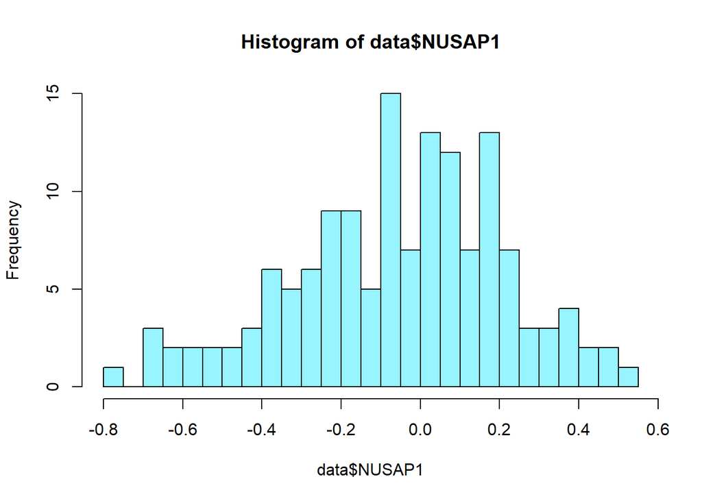

```r
hist(data$NUSAP1, breaks=20, col = c("cadetblue1"))
```

You can improve the plot by providing a title (`main`) and removing the x label and y label:

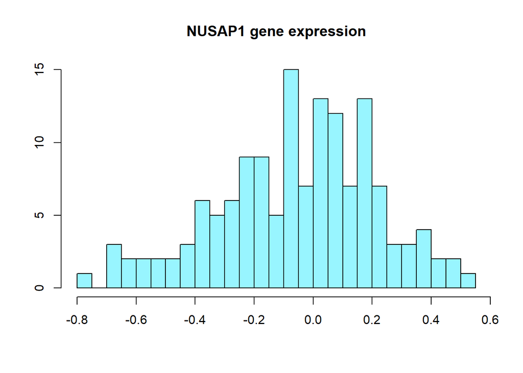

```r
hist(data$NUSAP1, breaks=20, col = c("cadetblue1"), main="NUSAP1 gene expression", xlab=NULL, ylab=NULL)
```

## 3.2 Histograms with ggpubr

`gghistogram()`: ggpubr function to create a histogram. Option `add = "mean"` adds a vertical line at the mean value. You can use also `add = "median"` or even `add = c("mean","median")`. Option `rug = TRUE` adds small segments on the x axis corresponding to each observation.

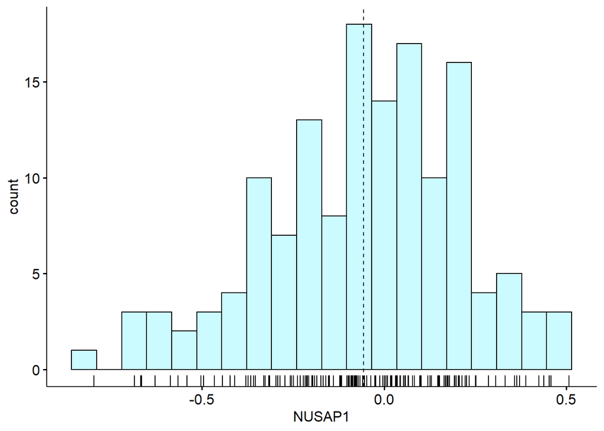

```r
gghistogram(data, x="NUSAP1",
            add = "mean", rug = TRUE,
            fill = "cadetblue1",
            bins = 20)
```

By simply adding the option `color = "event"`we obtain two different histograms according to metastasis indicator (variable event):

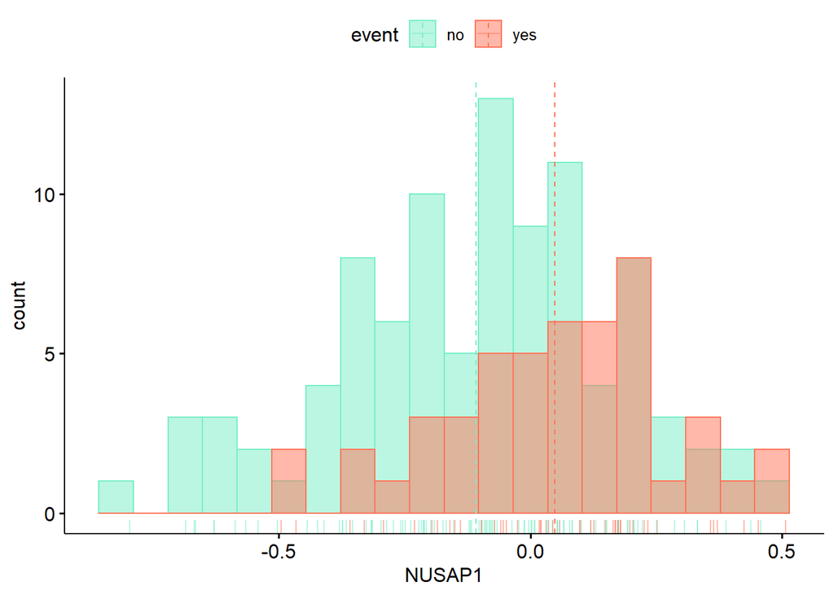

```r
gghistogram(data, x="NUSAP1",
            add = "mean", rug = TRUE,
            color = "event", fill = "event",
            bins = 20,
            palette = c("aquamarine2", "coral1"))
```

You can easily perform histograms of several variables by specifying their names in `x`.

**Example**: Object `p` creates two histograms, one for gene NUSAP1 and one for gene MMP9:

```r
p<-gghistogram(data, x=c("NUSAP1","MMP9"),
            add = "mean", rug = TRUE,
            color = "event", fill = "event",
            bins = 20,
            palette = c("aquamarine2", "coral1"))
```

By specifying `p$variablename` you obtain the histogram for each variable:

Histogram of NUSAP1:

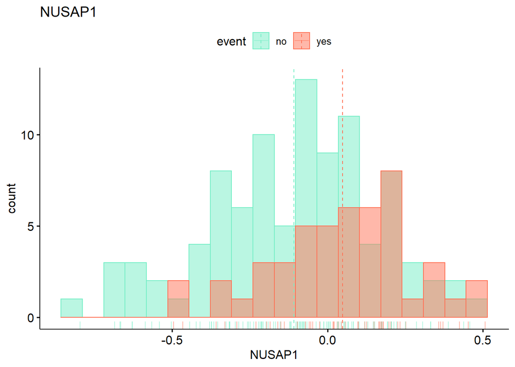

```r
p$NUSAP1
```

Histogram of MMP9:

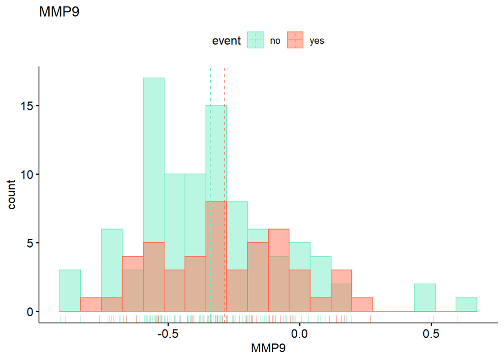

```r
p$MMP9
```

You can put both histograms side-by-side by adding the option `combine = T`:

**Example**: Histograms for gene NUSAP1 and for gene MMP9 alongside each other:

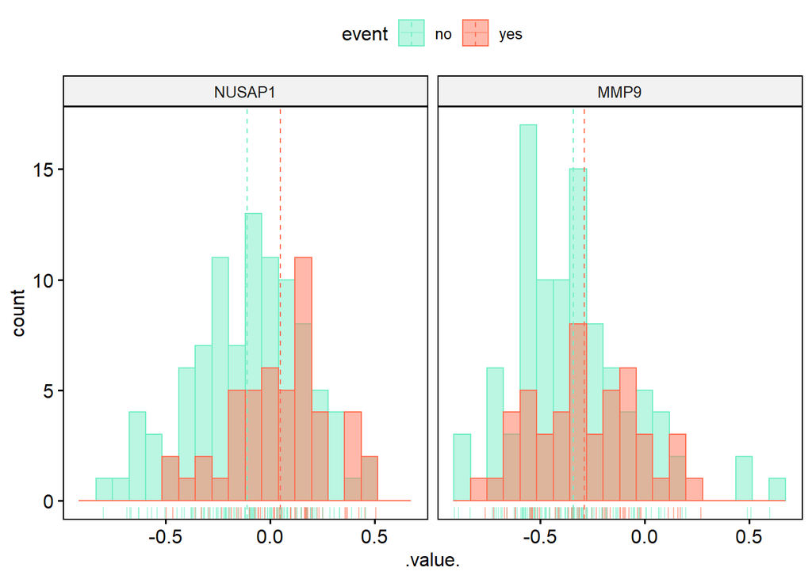

```r
gghistogram(data, x=c("NUSAP1","MMP9"),
            add = "mean", rug = TRUE,
            combine = T,
            color = "event", fill = "event",
            bins = 20,
            palette = c("aquamarine2", "coral1"))
```

Function `ggpar()` can be used to specify some graphical parameters outside the plot. This is useful to obtain different displays of the same plot.

**Example**: Histogram of gene NUSAP1 expression levels (p) with some graphical parameters (palette, main and caption) specified outside the plot with function `ggpar()`:

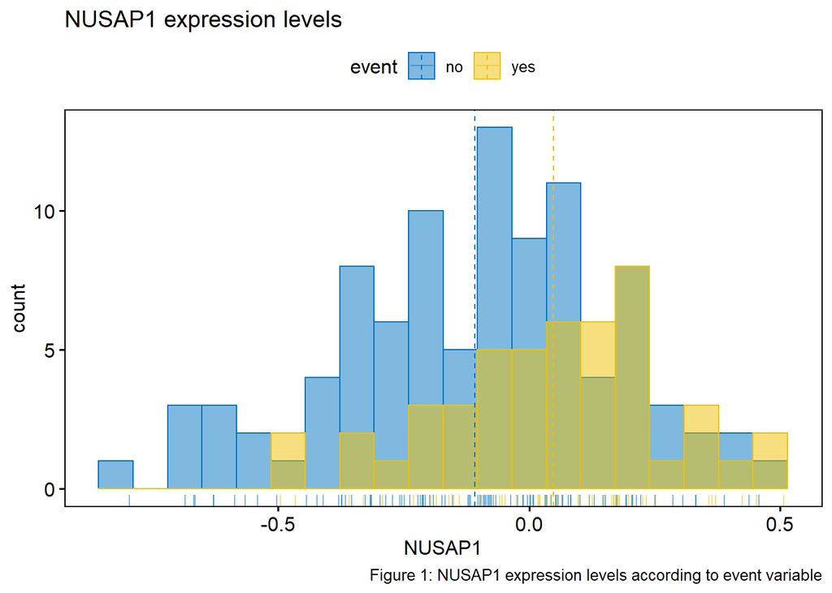

```r
p<-gghistogram(data, x="NUSAP1",
            add = "mean", rug = TRUE,
            combine = T,
            color = "event", fill = "event",
            bins = 20)

ggpar(p, palette = "jco", main="NUSAP1 expression levels", caption = "Figure 1: NUSAP1 expression levels according to event variable")
```

# 4 Density plots

Density plots, as histograms, provide a visual representation of the variation of a numerical variable. A density plot is a smoothed version of a histogram.

## 4.1 Base R density plots

`density()`: Base R function that provides an estimation of the density function of a variable.

**Example**: Density plot for NUSAP1:

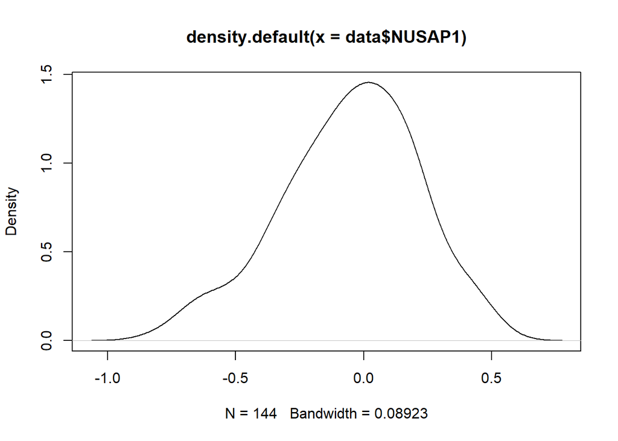

```r
plot(density(data$NUSAP1))
```

You can improve the plot by, for instance, specifying a title, the color line and a vertical line corresponding to the mean expression values using function `abline()`. Option `lty` specifies the type of line and `lty=3` corresponds to a dotted line:

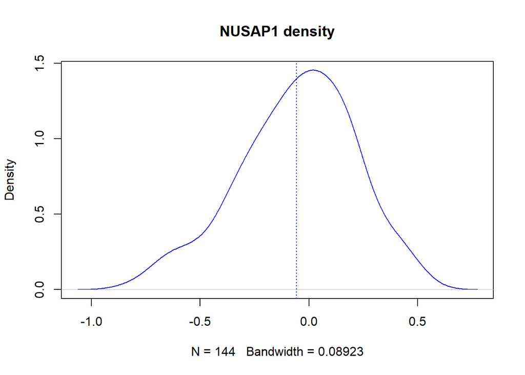

```r
plot(density(data$NUSAP1), main="NUSAP1 density", col="blue")
abline(v=mean(data$NUSAP1), col="blue", lty=3)
```

## 4.2 Density plots with ggpubr

`ggdensity()`: ggpubr function to create a density plot. Similar graphical options as in `gghistogram`are available. For instance, option `add = "mean"`or `add = "median"` adds a vertical line with x value equal to the mean or the median, respectively. Option `rug = TRUE` adds small segments on the x axis corresponding to each observation.

**Example**: Density plot for NUSAP1 with a vertical line corresponding to the median value:

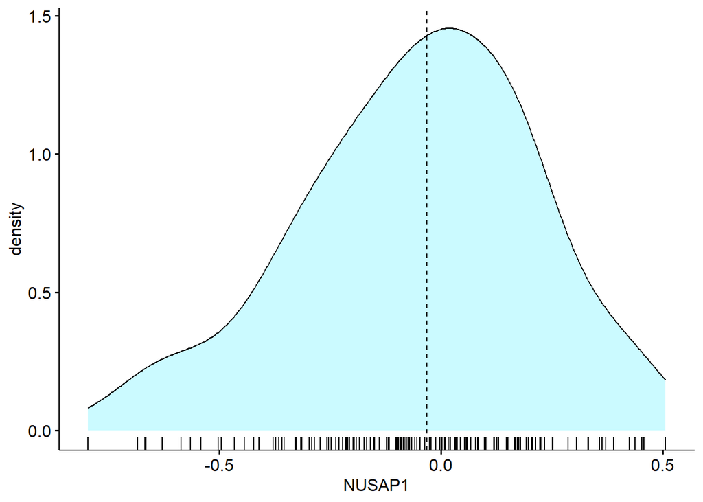

```r
ggdensity(data, x="NUSAP1",
            add = "median", rug = TRUE,
            fill = "cadetblue1")
```

By adding `color = categorical_variable_name`you obtain the density plots according to the different categories.

**Example:** Density plot of NUSAP1 expression levels according to metastasis indicator (“event”):

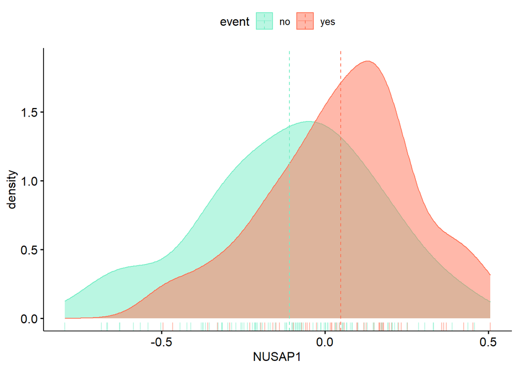

```r
ggdensity(data, x="NUSAP1",
            add = "mean", rug = TRUE,
            color = "event", fill = "event",
            palette = c("aquamarine2", "coral1"))
```

You can perform density plots of different variables by specifying their names in parameter “x”:

**Example:** Density plots of NUSAP1 and MMP9 gene expression levels (p):

```r
p<-ggdensity(data, x=c("NUSAP1","MMP9"),
               add = "mean", rug = TRUE,
               color = "event", fill = "event",
               palette = c("aquamarine2", "coral1"))
```

You can call every density plot as `p$variable_name`.

Density plot for NUSAP1 gene:

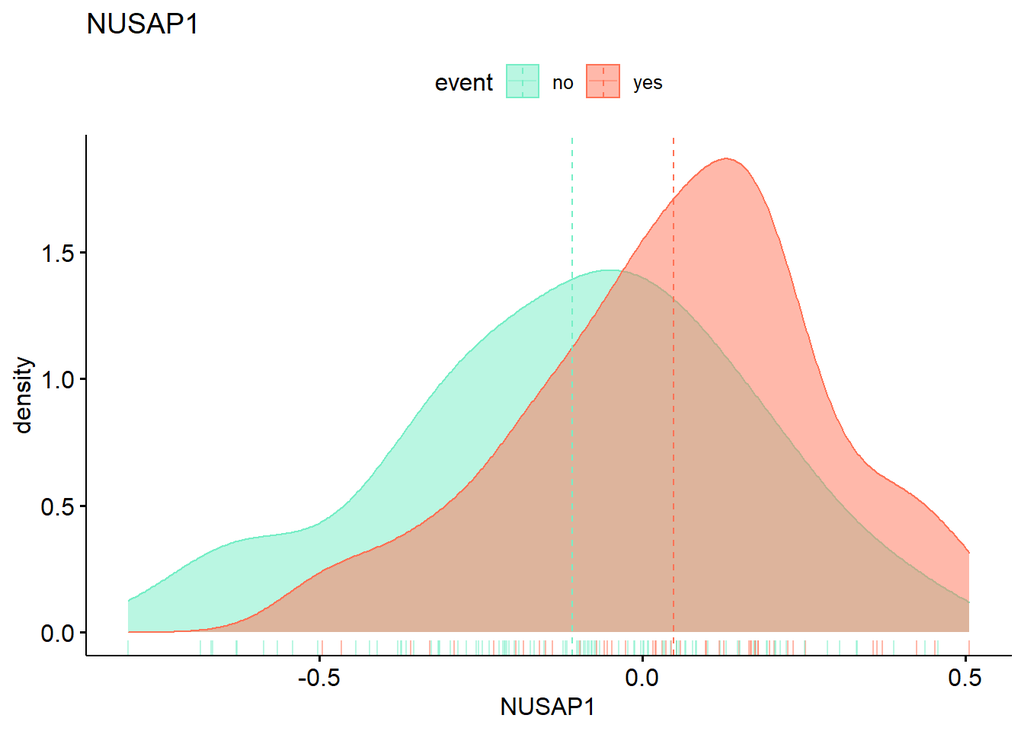

```r
p$NUSAP1
```

Density plot for MMP9 gene:

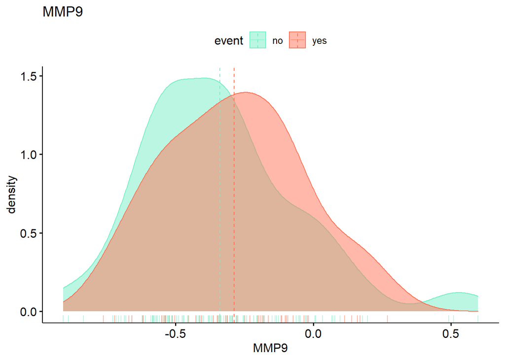

```r
p$MMP9
```

You can put the different density plots together by using the option `combine = T`:

**Example:** Density plots of NUSAP1 and MMP9 gene expression levels (p) combined:

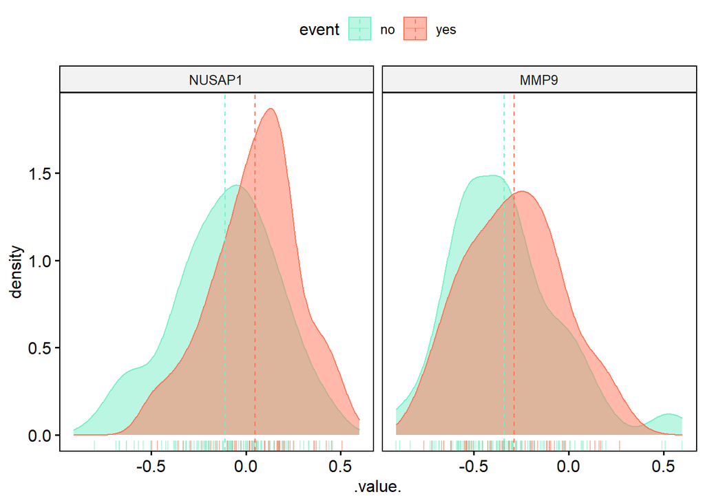

```r
ggdensity(data, x=c("NUSAP1","MMP9"),
            add = "mean", rug = TRUE,
            combine = T,
            color = "event", fill = "event",
            palette = c("aquamarine2", "coral1"))
```

## 4.3 Density plots of theoretical distributions

`curve()`: Function to obtain the plot of the density function of a theoretical distribution on a range of values specified by `xlim=c(a,b)`.

**Example**: Density function of a normal distribution with $\mu =3$ and $\sigma=0.6$:

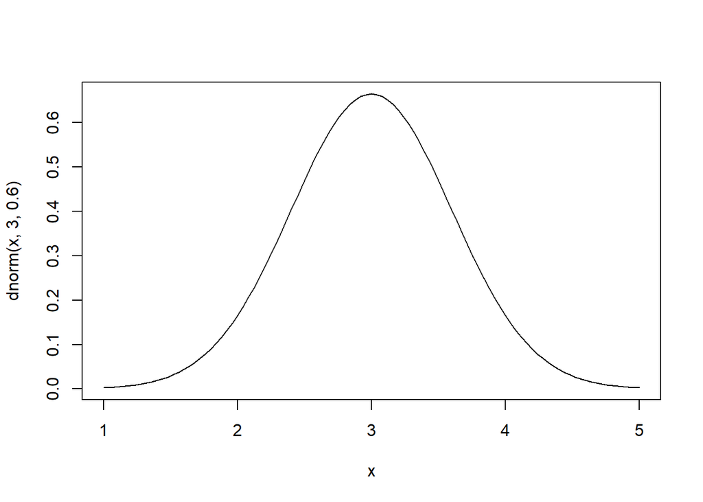

```r
curve(dnorm(x,3,0.6), xlim=c(1,5))
```

**Example**: You can add a second curve in the same plot by using `add=T`. Here we add the curve of a normal distribution with $\mu =2$ and $\sigma=1$ to the previous plot and also vertical lines at the mean for both curves. Option `lty=3` specifies the type of line:

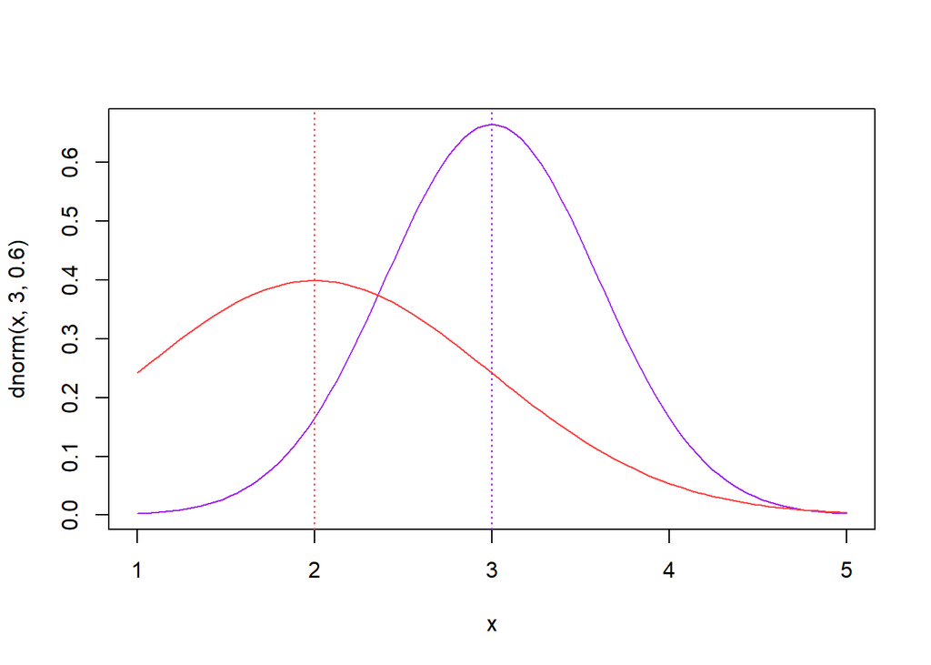

```r
curve(dnorm(x,3,0.6), xlim=c(1,5), col="purple")
curve(dnorm(x,2,1), add=T, col="brown1")
abline(v=3, col="purple", lty=3)
abline(v=2, col="brown1", lty=3)
```

`polygon()`: this function can be used to color the area under a density curve. You should provide `x` and `y`, the coordinates of the vertices of the polygon. It is assumed that the polygon is to be closed by joining the last point to the first point.

**Example**: Density function of a F distribution with degrees of freedom 15 and 5. We use the function `polygon()` to color the area under the curve for values of x between 1.5 and 3:

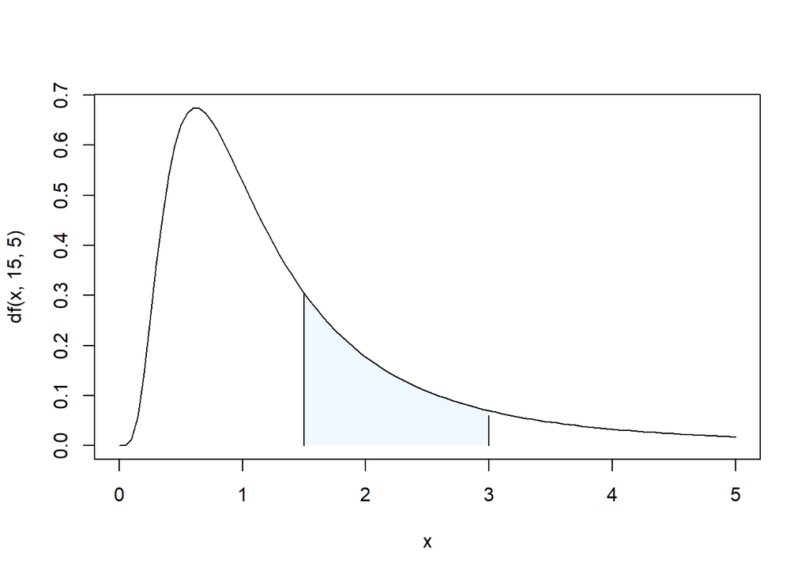

```r
curve(df(x,15,5), xlim=c(0,5))
x2 <- seq(1.5,3,0.01)
y2 <-  df(x2, 15, 5)
x2 = c(1.5,x2,3)
y2 = c(0,y2,0)
polygon(x2,y2, col="aliceblue", border=NA)
polygon(rep(1.5,length(y2)),y2, border=T)
y3<-seq(0,df(3,15,5),0.01)
polygon(rep(3,length(y3)),y3, border=T)
curve(df(x,15,5), xlim=c(0,5), add=T)   # we add again the curve on top of the colored region
```

**Example**: Density function of a normal distribution with with $\mu =0$ and $\sigma=1$ with the right tail colored beyond 1.25:

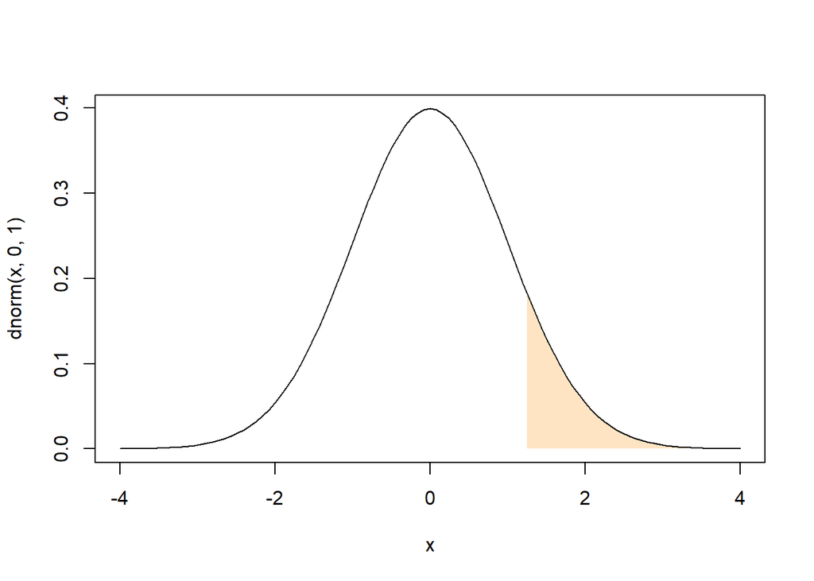

```r
curve(dnorm(x,0,1), xlim=c(-4,4))
x2 <- seq(1.25,4,0.01)
y2 <-  dnorm(x2, 0, 1)
x2 = c(1.25,x2,4)
y2 = c(0,y2,0)
polygon(x2,y2, col="bisque", border=NA)
curve(dnorm(x,0,1), xlim=c(-4,4), add = TRUE)
```

# 5 Boxplots

A boxplot, also called box and whisker plot, is used to represent the variation of a continuous numerical variable. It displays the minimum, first quartile, median, third quartile, and maximum and also possible outliers: https://www.khanacademy.org/math/statistics-probability/summarizing-quantitative-data/box-whisker-plots/a/box-plot-review

## 5.1 Base R Boxplots

`boxplot()`: Base R function to obtain the boxplot of a numerical variable.

**Example:** Boxplot of expression levels of gene NUSAP1:

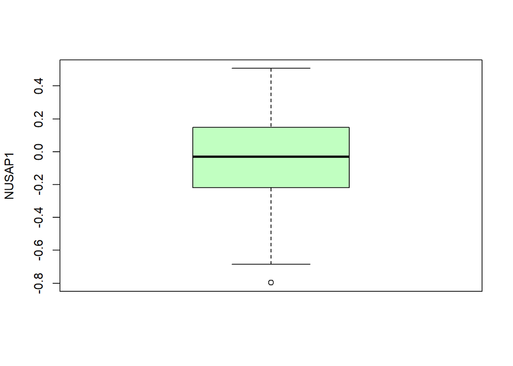

```r
boxplot(data$NUSAP1, ylab="NUSAP1", col="darkseagreen1")
```

A **multiple boxplot** of a numerical variable `y` according to the different groups of a categorical variable `x` is obtained as `boxplot(y~x)`.

**Example:** Boxplot of expression levels of gene NUSAP1 according to Grade:

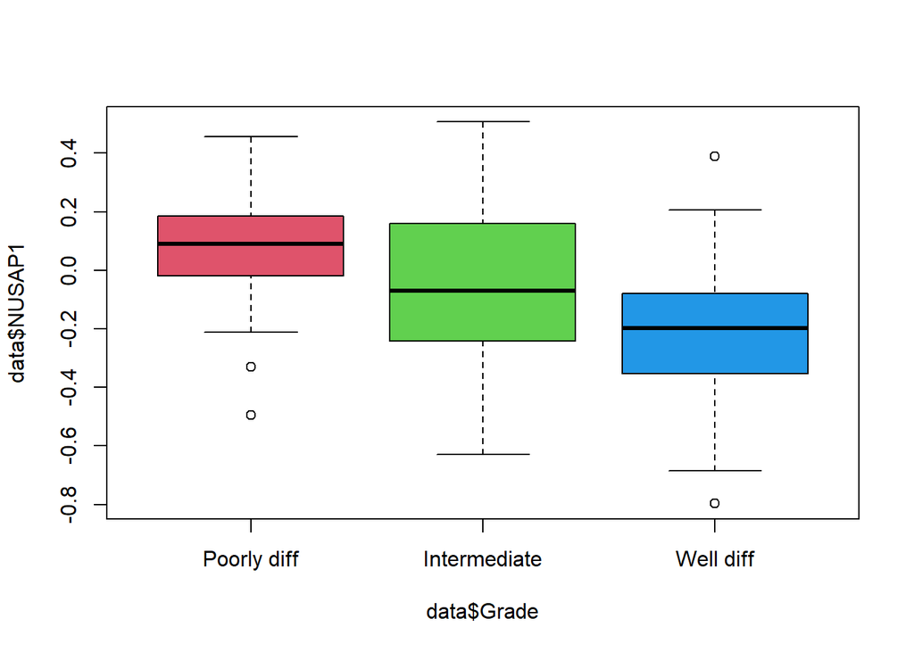

```r
boxplot(data$NUSAP1~data$Grade, col=c(2,3,4))
```

## 5.2 Boxplots with ggpubr

`ggboxplot()`: ggpubr function to obtain the boxplot of a numerical variable `y`.

**Example:** Boxplot of expression levels of gene NUSAP1. Option `add="point"`adds a point for each observation.

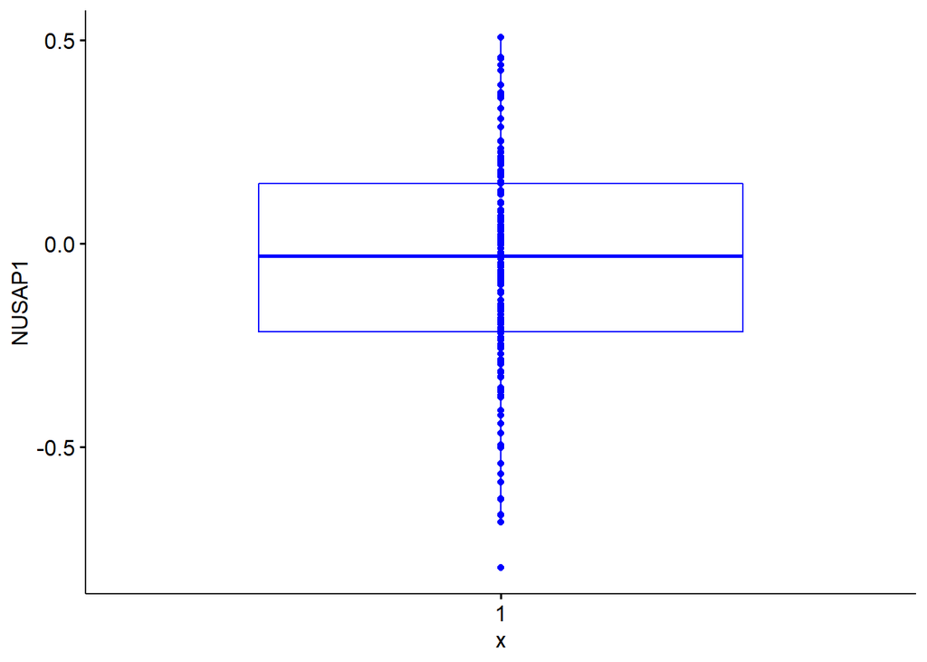

```r
ggboxplot(data, y="NUSAP1",
          add="point",
          color = "blue")
```

Option `add=jitter` moves the points randomly around the vertical line so that the observations are not overlapped.

**Example:** Boxplot of NUSAP1 values with `jitter`. As observed in the previous plots, the minimum expression value of NUSAP1 is an outlier. We can identify which observation is the outlier by using the option `label.select = list(top.down = 1)`:

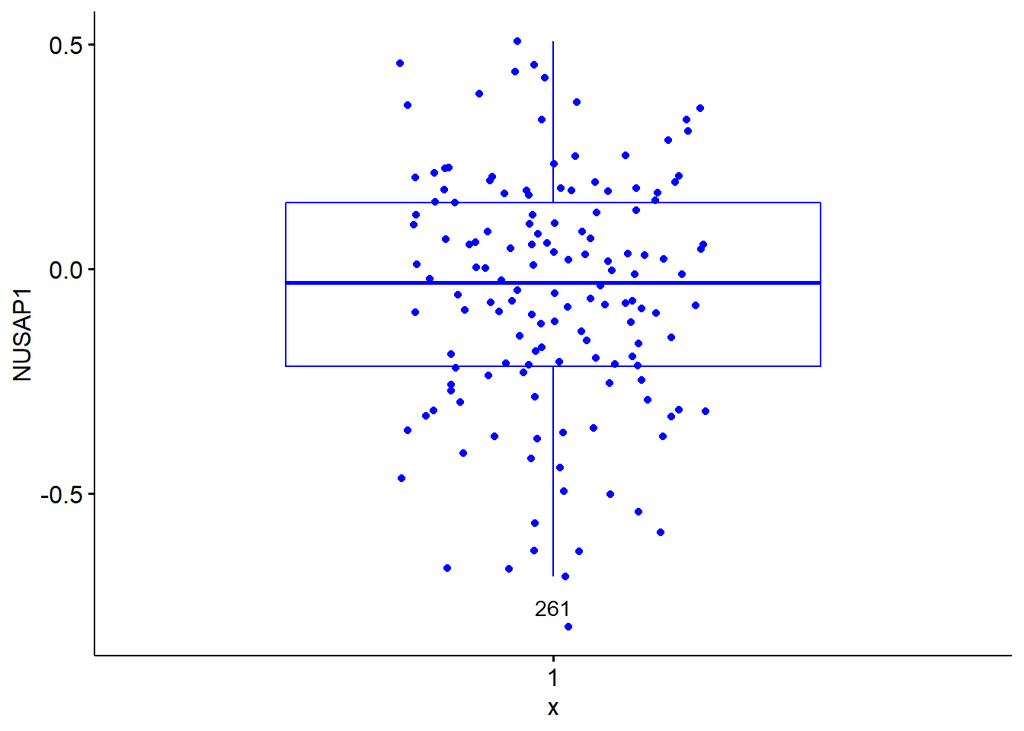

```r
ggboxplot(data, y="NUSAP1",
          color = "blue", add = "jitter",
          label=rownames(data),
          label.select = list(top.down = 1))
```

The size of the points and the jitter width can be modified with option `add.params`:

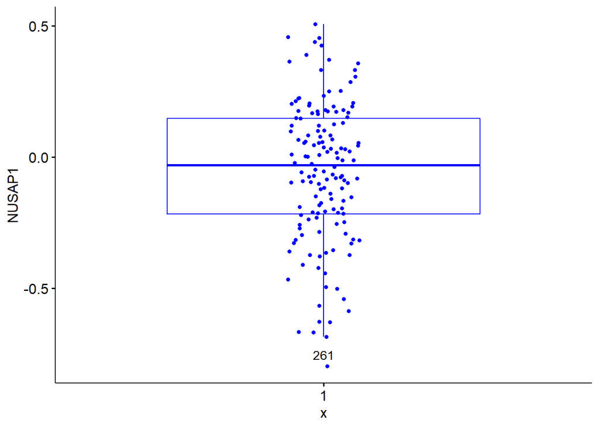

```r
ggboxplot(data, y="NUSAP1",
          color = "blue",
          add = "jitter", add.params = list(size = 1.2, jitter = 0.08),
          label=rownames(data),
          label.select = list(top.down = 1))
```

A **multiple boxplot** can be obtained by specifying a categorical variable `x` in addition to the numerical variable `y`.

**Example:** Boxplot of NUSAP1 expression levels according to tumour grade:

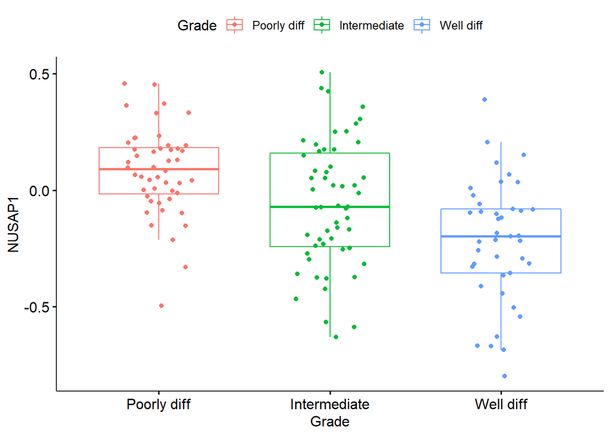

```r
ggboxplot(data, x = "Grade", y = "NUSAP1",
               color = "Grade", palette ="hue",
               add = "jitter")
```

We can change the shape of the points with option `shape`:

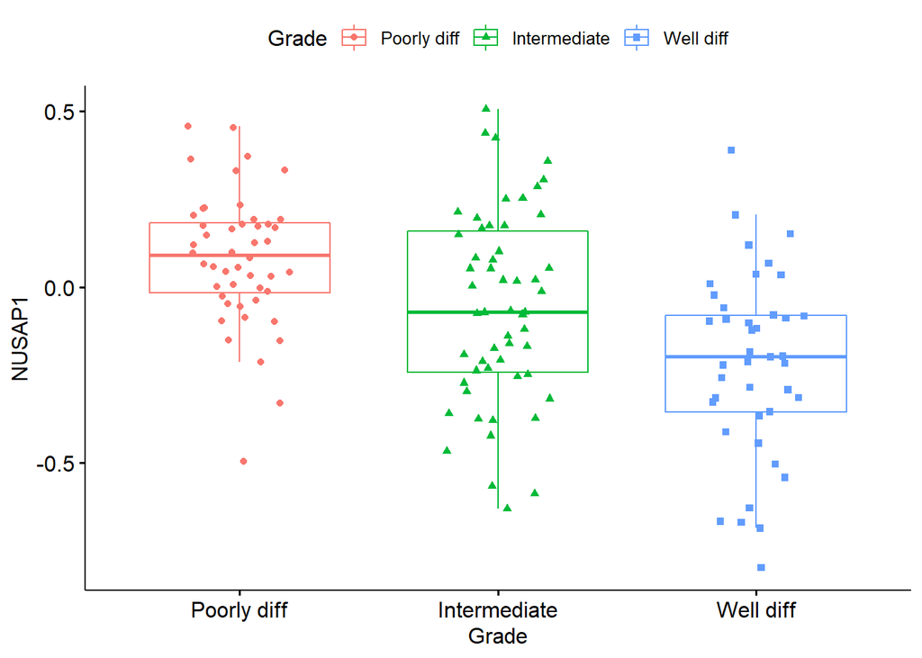

```r
ggboxplot(data, x = "Grade", y = "NUSAP1",
               color = "Grade", palette ="hue",
               add = "jitter", shape = "Grade")
```

**Multiple boxplots of several numerical variables:**

You can perform multiple boxplot of several numerical variables by specifying their name in `y`.

**Example:** Boxplots of NUSAP1 and DIAPH3 expression levels according to tumour grade. Option `combine = TRUE` puts both plots side-by-side:

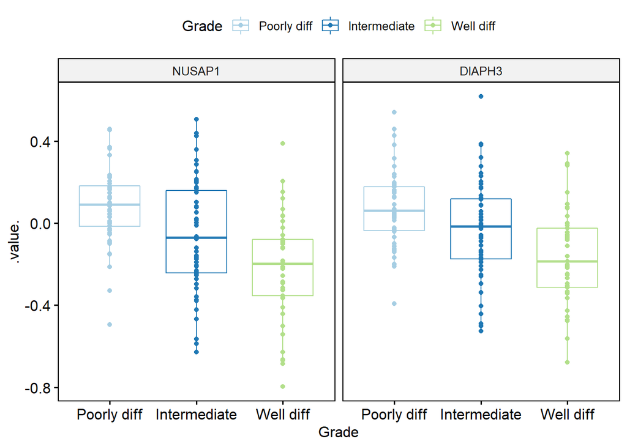

```r
 ggboxplot(data, x = "Grade", y = c("NUSAP1","DIAPH3"),
               combine = TRUE,
               color = "Grade", palette = "Paired",
               add = "point", shape = "Grade")
```

**Multiple boxplots according to two categorial variables:**

You can perform a multiple boxplot of a numerical variable according to two categorical variables, one is specified as `x` and the other with function `color`.

**Example:** Boxplot of NUSAP1 expression levels according to tumour grade and ER (estrogen receptor status):

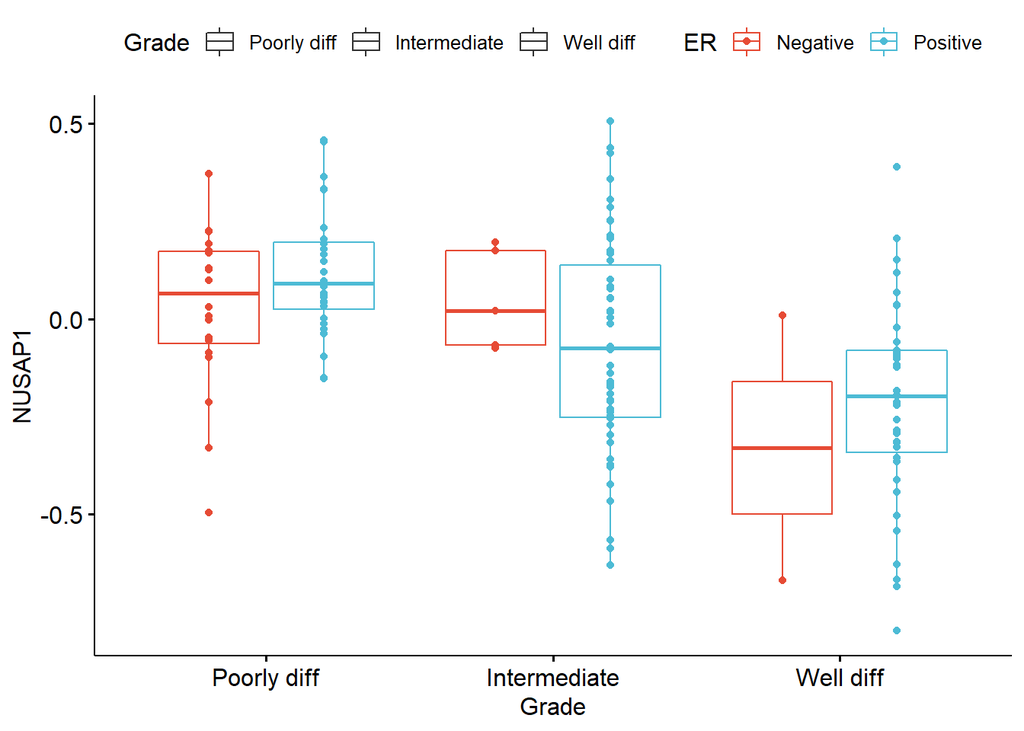

```r
 ggboxplot(data, x = "Grade", y = c("NUSAP1"),
               color = "ER", palette = "npg",
               add = "point", shape = "Grade")
```

Alternatively, you can perform a multiple boxplot of a numerical variable according to two categorical variables, one is specified as `x` and the other with function `facet.by =`.

**Example:** Boxplot of NUSAP1 expression levels according to tumour grade and ER (estrogen receptor status):

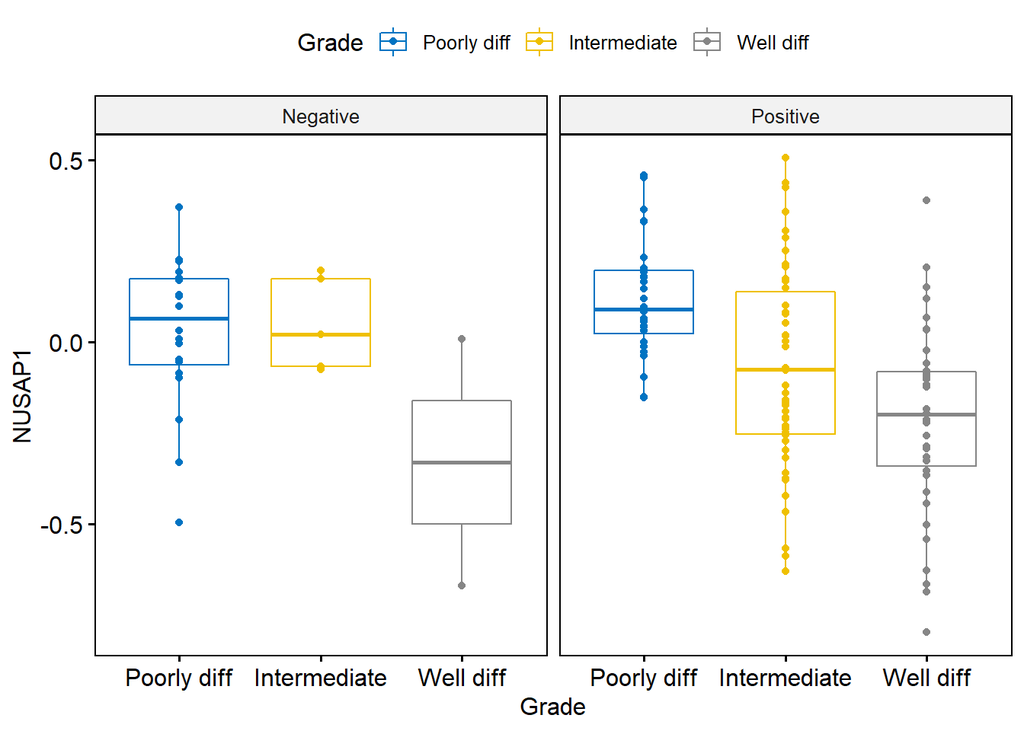

```r
 ggboxplot(data, x = "Grade", y = c("NUSAP1"),
              facet.by = "ER",
               color = "Grade", palette = "jco",
               add = "point", shape = "Grade")
```

**Add p-values:**

`stat_compare_means()`: This ggpubr function provides a very simple way of adding mean comparison p-values to a boxplot. The default option implements non parametric tests: the Wilcoxon test (two categories) and Krukal-Wallis test (more than two categories).

You can learn more about adding p-values to ggplots here: http://www.sthda.com/english/articles/24-ggpubr-publication-ready-plots/76-add-p-values-and-significance-levels-to-ggplots/